# CS624 Quiz2

Duc Le

11/19/2020

### Problem 1

```r
library(faraway)
library(ROSE)
library(AER)
library(plyr)
library(MASS)
library(dplyr)
library(foreign)

data(wcgs)
```

#### 1a)

```r
new.wcgs = na.omit(wcgs)
attach(new.wcgs)
new.wcgs$arcus = as.factor(ifelse(new.wcgs$arcus == "absent", 0, 1))
new.wcgs$typechd = as.factor(ifelse(new.wcgs$typechd == "none", 0, 1))
new.wcgs$chd = as.factor(ifelse(new.wcgs$chd == "no", 0, 1))
new.wcgs$dibep = as.factor(ifelse(new.wcgs$dibep == "A", 0, 1))

values = levels(behave)
new.wcgs$behave = mapvalues(factor(new.wcgs$behave), from = values, to = seq(length(values)))

new.wcgs = new.wcgs %>% select(-c(timechd, typechd, behave))
```

#### 1b)

```r
base = glm(dibep~., data = new.wcgs, family = "binomial")
final1 = stepAIC(base, trace = 0)

summary(final1)
```

```
##
## Call:
## glm(formula = dibep ~ age + height + sdp + chol + cigs + chd,
##     family = "binomial", data = new.wcgs)
##
## Deviance Residuals:
##     Min       1Q   Median       3Q      Max
## -1.8747  -1.1392   0.7039   1.1674   1.4753
##
## Coefficients:
##               Estimate Std. Error z value Pr(>|z|)
## (Intercept) -4.8436316  1.1383946  -4.255 2.09e-05 ***
## age          0.0275033  0.0067612   4.068 4.75e-05 ***
## height       0.0325907  0.0145338   2.242  0.02493 *
## sdp          0.0065838  0.0024929   2.641  0.00826 **
## chol         0.0012634  0.0008613   1.467  0.14244
## cigs         0.0112907  0.0025458   4.435 9.21e-06 ***
## chd1         0.6695975  0.1450775   4.615 3.92e-06 ***
## ---
## Signif. codes:  0 '***' 0.001 '**' 0.01 '*' 0.05 '.' 0.1 ' ' 1
##
## (Dispersion parameter for binomial family taken to be 1)
##
##     Null deviance: 4352.7  on 3139  degrees of freedom
## Residual deviance: 4255.9  on 3133  degrees of freedom
## AIC: 4269.9
##
## Number of Fisher Scoring iterations: 4
```

The model was able to predict dibep best by using age + height + sdp + chol + cigs and chd. Quick overview of the coefficients: All of the features chosen are statistiscally significant with the exception of chol.

#### 1c)

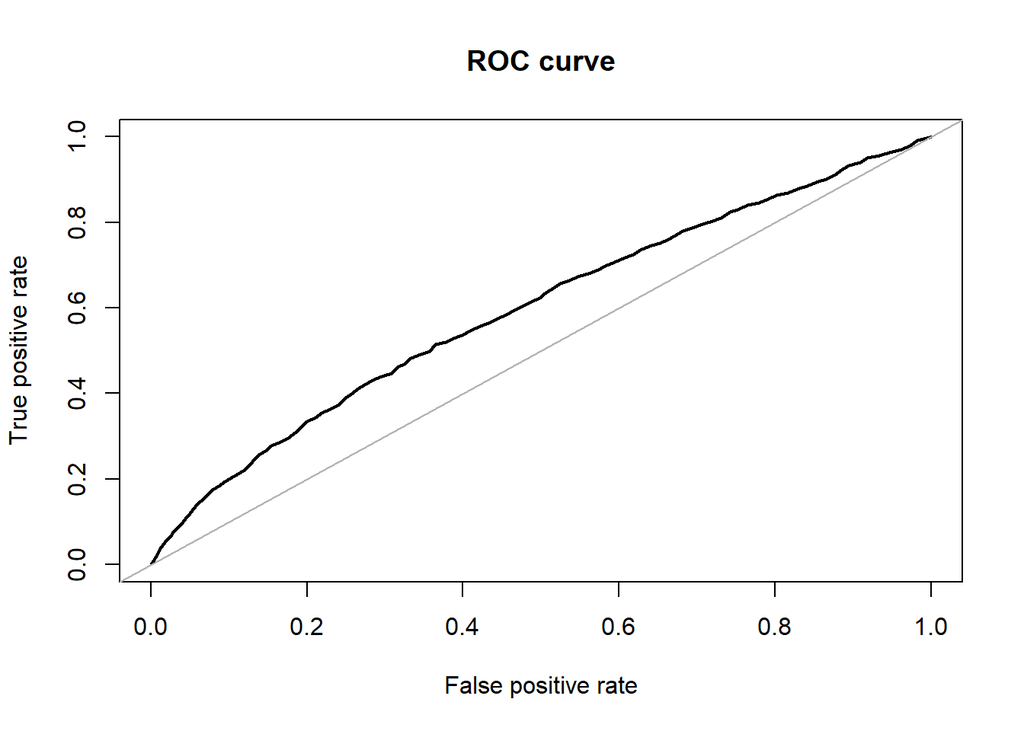

```r
pp1 = predict(final1, type = "response")
roc1 = roc.curve(dibep, pp1)
```

```r
roc1
```

```
## Area under the curve (AUC): 0.596
```

The AUC obtained under the ROC is 0.596. This is obviously not an ideal AUC score we’re striving for. However, given the limited time of the exam, I cannot afford to further investigate to why the model yielded an undesireable AUC score.

#### 1d)

```r
best_threshold_index = which.max(roc1$true.positive.rate - roc1$false.positive.rate)
roc1$thresholds[best_threshold_index]
```

```
## [1] 0.5045996
```

#### 1e)

```r
final2 = stepAIC(base, ~.^2, trace = 0)
final3 = stepAIC(base, ~.^3, trace = 0)

pp2 = predict(final2, type = "response")
roc2 = roc.curve(dibep, pp2)
roc2
```

```
## Area under the curve (AUC): 0.601
```

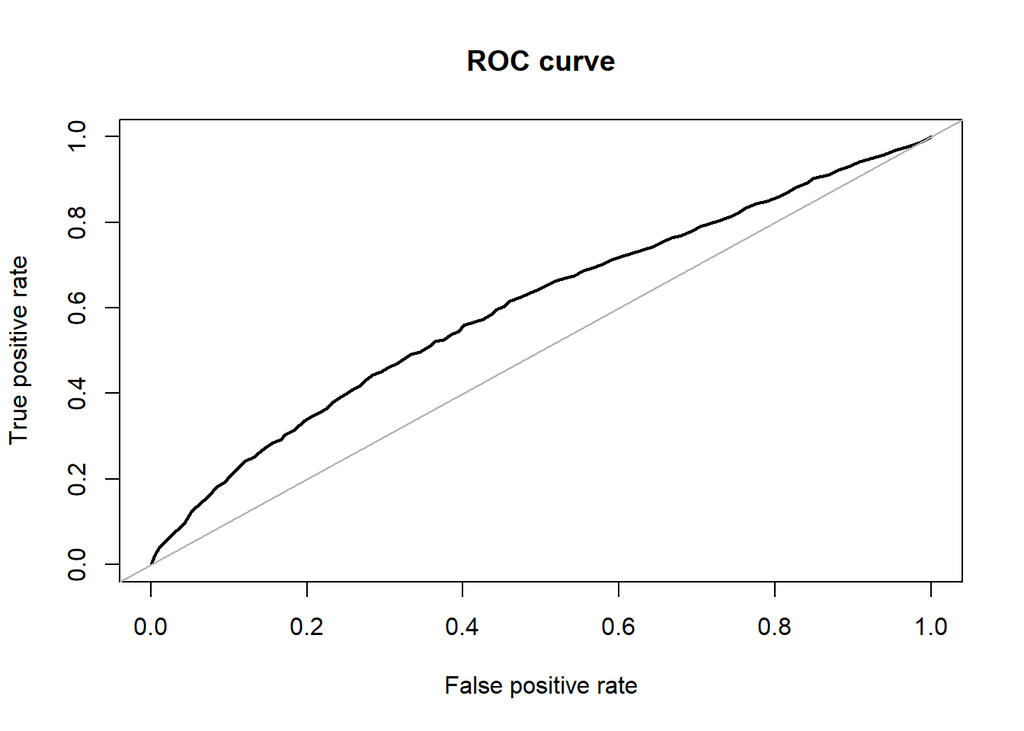

```r
pp3 = predict(final3, type = "response")
roc3 = roc.curve(dibep, pp3)
```

```r
roc3
```

```
## Area under the curve (AUC): 0.601
```

The 2 new models yield the same results in terms of the AUC score. They both performed better than the original log model that did not have interactions.

#### 1f)

The first logistic model performed poorly, only having an AUC of 0.596. The following 2 interactive models performed slightly better. A guess on this improvement could be because some features are dependent on one another, thus 2 & 3 way interactions between them will yield better results. If given more time, an approach I could do to improve the accuracy + AUC of all these models could be to look more into the variables’ meanings & do a better job of feature selecting.

### Problem 2

#### 2a)

```r
d = read.table("https://data.princeton.edu/wws509/datasets/ships.dat")

poisson.base = glm(damage~., offset(log(months)), data = d, family = poisson)
poisson.final = stepAIC(poisson.base, trace = 0)
```

#### 2b)

```r
1 - pchisq(poisson.final$deviance, poisson.final$df.residual)
```

```
## [1] 0
```

#### 2c)

```r
dispersiontest(poisson.final)
```

```
##
##  Overdispersion test
##
## data:  poisson.final
## z = 2.6742, p-value = 0.003745
## alternative hypothesis: true dispersion is greater than 1
## sample estimates:
## dispersion
##   1.956256
```

The dispersion is 1.956 which is over 1.

#### 2d)

```r
quasi.poisson =  glm(poisson.final$call, family = quasipoisson, data = d)
summary(quasi.poisson)
```

```
##
## Call:
## glm(formula = poisson.final$call, family = quasipoisson, data = d)
##
## Deviance Residuals:
##     Min       1Q   Median       3Q      Max
## -2.5484  -1.3867  -0.4307   0.5222   3.1152
##
## Coefficients:
##                       Estimate Std. Error t value Pr(>|t|)
## (Intercept)          1.786e-01  4.587e-01   0.389 0.700447
## typeB                6.701e-01  3.595e-01   1.864 0.074653 .
## typeC               -1.192e+00  5.422e-01  -2.198 0.037863 *
## typeD               -8.294e-01  4.763e-01  -1.741 0.094420 .
## typeE               -1.493e-01  3.888e-01  -0.384 0.704284
## construction1965-69  1.087e+00  2.967e-01   3.665 0.001224 **
## construction1970-74  1.500e+00  3.721e-01   4.031 0.000487 ***
## construction1975-79  8.545e-01  4.568e-01   1.871 0.073628 .
## operation1975-79     7.284e-01  2.246e-01   3.243 0.003461 **
## months               6.697e-05  1.411e-05   4.746 7.92e-05 ***
## ---
## Signif. codes:  0 '***' 0.001 '**' 0.01 '*' 0.05 '.' 0.1 ' ' 1
##
## (Dispersion parameter for quasipoisson family taken to be 2.740679)
##
##     Null deviance: 614.539  on 33  degrees of freedom
## Residual deviance:  70.498  on 24  degrees of freedom
## AIC: NA
##
## Number of Fisher Scoring iterations: 5
```

```r
1 - pchisq(quasi.poisson$deviance, quasi.poisson$df.residual)
```

```
## [1] 1.837649e-06
```